# Voting rights and the HR2W: Initial analysis and next steps brainstorm

Kristin Dobbin

2023-06-23

### Construction of independent variables of interest

The below table provides a first draft at these two independent variables of interest for all 28 institutional types identified in the 2023 update, with two versions of the voting enfranchisement variable displayed for consideration. The first voting variable (“voting”), excludes from consideration (“NA”) institutional types without governing boards (generally ancillary systems that exist for a primary purpose other than water provision). For example, state and federal systems that are recreation and carceral facilities and private ancillary systems that are private businesses including farms, packing houses, industrial parks etc. The remainder of types are classified as either having no resident voting for the governing board, limited resident voting (ie limited to landowners) or full resident voting (ie all registered voters in district can vote). Alternatively, the second version of the voting variable (“Voting3”) includes ancillary systems without governing boards in the category of “none” for the purposes of characterizing resident enfranchisement (in other words, groups together systems without a board with those where there is a board but it is not elected). Either one of these two variables could be used in the analysis or a different approach altogether could be used (e.g. two variables, one for existence of the board and one for voter enfranchisement where there is a board).

Finally, the “board” variable indicates the extent to which registered voter residents of the district are eligible to serve on the board themselves. Full means any registered voter can serve. Limited means only landowners can serve and none means there is either no board or the board is not comprised of local residents (so more similar to the voting3 variable). The big issue with this variable is that the public/governmental districts are limited to registered voters which necessitates citizenship which is not true of private types, most notable Mutual Benefit systems. It is hard to capture both of these considerations in one variable.

In each of the three variables, Tribal government institutional types and the unknown private system types are excluded from consideration. The later due to lack of information and the former as outliers due to their unique political structures as sovereign nations. Institutional types where voting enfranchisement or board eligibility is variable per California Code are currently listed as “variable”. My plan is to code these 90-100 systems individually.

| 2023 Institution types | Voting | Voting3 | Board |
| --- | --- | --- | --- |
| California Water District | Variable | Variable | Limited |
| City | Full | Full | Full |
| Community Services District | Full | Full | Full |
| County | NA | None | None |
| County Sanitation District | Full | Full | Variable |
| County Service Area | Full | Full | Full |
| County Water District | Full | Full | Full |
| County Waterworks District | Full | Full | Full |
| Federal | NA | None | None |
| Investor Owned Utility | None | None | None |
| Irrigation District | Limited | Limited | Variable |
| Joint Powers Authority/Agreement | Variable | Variable | Variable |
| Maintenance District | Full | Full | Full |
| Mobile Home Park | NA | None | None |
| Municipal Utility District | Full | Full | Full |
| Municipal Water District | Full | Full | Full |
| Mutual Benefit | Limited | Limited | Limited |
| Private - Unknown | NA | NA | NA |
| Private - Ancillary | NA | None | None |
| Public Utility District | Full | Full | Full |
| Resort Improvement District | Full | Full | Full |
| Resource Conservation District | Full | Full | Full |
| Sanitary District | Full | Full | Full |
| School District | NA | None | None |
| Special Act District | Variable | Variable | Variable |
| State | NA | None | None |
| Tribal Government | NA | NA | NA |
| Water Conservation District | Full | Full | Full |

#### Questions for feedback: What do you think about these three variables? How could they be improved? Which is most compelling/informative in terms of an anlysis of system performance? Do you disagree wtih any of the characterizations or see any mistakes?

### Potential system performance/outcome variables

System performance, which can be measured in a variety of ways, is similarly diverse. California’s CWSs vary with respect to their SAFER Needs Assessment status which reflects different levels of risk across water quality, water accessibility, water affordability and Technical Managerial and Financial Capacity.

|  | Count | Percent of all systems |
| --- | --- | --- |
| At-Risk | 395 | 0.14 |
| Failing | 338 | 0.12 |
| Not Assessed | 156 | 0.05 |
| Not At-Risk | 1560 | 0.55 |
| Potentially At-Risk | 400 | 0.14 |
| NA’s | 11 | 0.00 |

| Mean_total_risk | Mean_quality_risk | Mean_accessibility_risk | Mean_affordability_risk | Mean_TMF_risk |
| --- | --- | --- | --- | --- |
| 2.284051 | 0.5369382 | 0.8525484 | 0.4852106 | 0.4102567 |

Notably, system risk or failing status reflects a complicated combination of factors and causes, not all of which are necessarily within the control of the governing board. Even assuming that voting and board representation matters, it is entirely feasible that a water system with robust representation and community participation is governance might still struggle if it is very small, has poor source water quality, has dilapidated infrastructure etc. Some additional potential outcomes for variation that may more clearly reflect the role of governance in system performance include funding received (likely still reflects risk some but also potentially reflects proactive efforts to fix issues?). 303 of CWSs have received state funding since 2017. Another potential option is whether a system applied for COVID-19 arrearage relief. We have data both on whether a system reported to the SWRCB that they intended to apply for the funding and if they did.

|  | Reported intending to apply | Percent of all systems |
| --- | --- | --- |
| Did not complete survey | 947 | 0.33 |
| N | 1 | 0.00 |
| No | 889 | 0.31 |
| Yes | 976 | 0.34 |
| NA’s | 47 | 0.02 |

|  | Applied | Percent of all systems |
| --- | --- | --- |
| No | 1932 | 0.68 |
| Yes | 881 | 0.31 |
| NA’s | 47 | 0.02 |

#### Questions for feedback: Are there other outcome or performance variables that would be interesting to look at? How can we ensure a “well rounded” assessment of water system performance as it relates to the human right to water and best hone in on the influence of governance?

### Exploratory results

Once the independent variables and outcomes of interest have been solidified, I will run some formal analyses using more appropriate statistical techniques but I include the following “rough” linear regressions to help illustrate what this analysis could look like (note covariates/controls currently not included, I plan to use at least service connections (or population) and source water, could include county).

```
##
## Call:
## lm(formula = Total_risk ~ voting3, data = Data)
##
## Residuals:
##     Min      1Q  Median      3Q     Max
## -2.5442 -1.0712 -0.2142  0.7858  7.4558
##
## Coefficients:
##                 Estimate Std. Error t value Pr(>|t|)
## (Intercept)      2.06117    0.05173  39.846  < 2e-16 ***
## voting3Limited   0.13258    0.07320   1.811   0.0702 .
## voting3None      0.48306    0.07157   6.749 1.83e-11 ***
## voting3Variable -0.17389    0.20679  -0.841   0.4005
## ---
## Signif. codes:  0 '***' 0.001 '**' 0.01 '*' 0.05 '.' 0.1 ' ' 1
##
## Residual standard error: 1.485 on 2598 degrees of freedom
##   (258 observations deleted due to missingness)
## Multiple R-squared:  0.01993,    Adjusted R-squared:  0.0188
## F-statistic: 17.61 on 3 and 2598 DF,  p-value: 2.563e-11
```

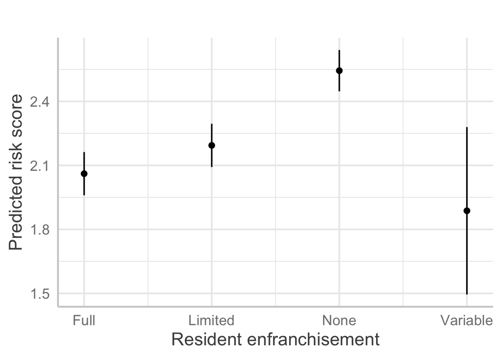

```
##
## Call:
## glm(formula = Application.complete. ~ voting3, family = binomial,
##     data = Data)
##
## Deviance Residuals:
##     Min       1Q   Median       3Q      Max
## -1.3368  -0.6755  -0.5428   1.0259   1.9940
##
## Coefficients:
##                 Estimate Std. Error z value Pr(>|z|)
## (Intercept)      0.36731    0.06727    5.46 4.76e-08 ***
## voting3Limited  -2.20800    0.12157  -18.16  < 2e-16 ***
## voting3None     -1.72885    0.10655  -16.23  < 2e-16 ***
## voting3Variable -0.70764    0.22535   -3.14  0.00169 **
## ---
## Signif. codes:  0 '***' 0.001 '**' 0.01 '*' 0.05 '.' 0.1 ' ' 1
##
## (Dispersion parameter for binomial family taken to be 1)
##
##     Null deviance: 3423.3  on 2729  degrees of freedom
## Residual deviance: 2929.3  on 2726  degrees of freedom
##   (130 observations deleted due to missingness)
## AIC: 2937.3
##
## Number of Fisher Scoring iterations: 4
```

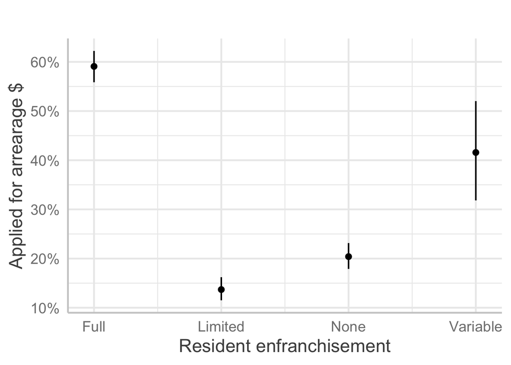

```
##
## Call:
## lm(formula = Total_risk ~ board, data = Data)
##
## Residuals:
##     Min      1Q  Median      3Q     Max
## -2.5442 -1.0717 -0.2142  0.7858  7.4558
##
## Coefficients:
##               Estimate Std. Error t value Pr(>|t|)
## (Intercept)    2.06000    0.05162  39.906  < 2e-16 ***
## boardLimited   0.18228    0.07341   2.483 0.013092 *
## boardNone      0.48423    0.07138   6.783 1.45e-11 ***
## boardVariable -0.60200    0.17852  -3.372 0.000757 ***
## ---
## Signif. codes:  0 '***' 0.001 '**' 0.01 '*' 0.05 '.' 0.1 ' ' 1
##
## Residual standard error: 1.48 on 2598 degrees of freedom
##   (258 observations deleted due to missingness)
## Multiple R-squared:  0.02636,    Adjusted R-squared:  0.02523
## F-statistic: 23.44 on 3 and 2598 DF,  p-value: 5.721e-15
```

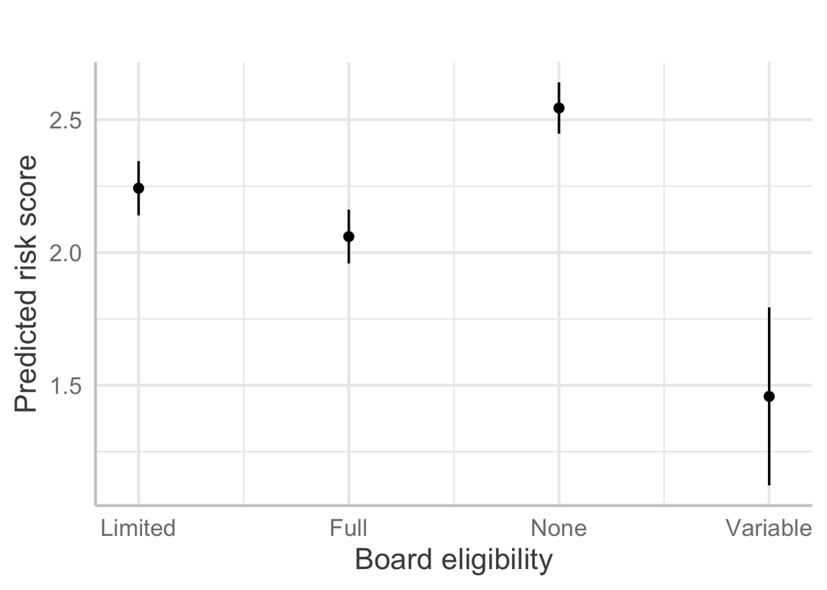

```
##
## Call:
## glm(formula = FundingYorN ~ board, family = binomial, data = Data)
##
## Deviance Residuals:
##     Min       1Q   Median       3Q      Max
## -0.7036  -0.7036  -0.3906  -0.2525   2.6311
##
## Coefficients:
##               Estimate Std. Error z value Pr(>|z|)
## (Intercept)   -1.26976    0.08003 -15.866  < 2e-16 ***
## boardLimited  -1.26526    0.15618  -8.101 5.44e-16 ***
## boardNone     -2.15977    0.20495 -10.538  < 2e-16 ***
## boardVariable -0.92746    0.32774  -2.830  0.00466 **
## ---
## Signif. codes:  0 '***' 0.001 '**' 0.01 '*' 0.05 '.' 0.1 ' ' 1
##
## (Dispersion parameter for binomial family taken to be 1)
##
##     Null deviance: 1898.4  on 2762  degrees of freedom
## Residual deviance: 1717.7  on 2759  degrees of freedom
##   (97 observations deleted due to missingness)
## AIC: 1725.7
##
## Number of Fisher Scoring iterations: 6
```

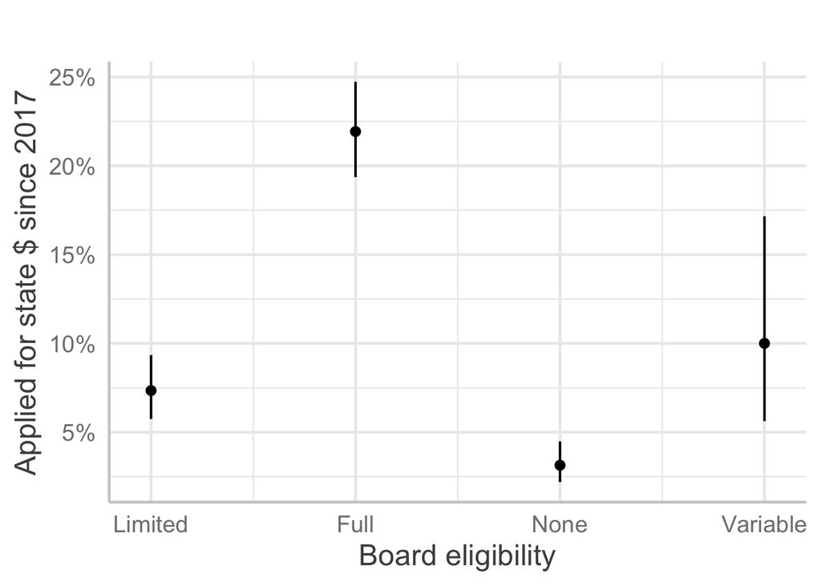